# Repetition

Statistical Programming with R

## Welcome back

## Programme

[output not shown]

## Format

- Lectures followed by practicals
- Materials are on the homepage
  - “Impracticals” are the versions without solutions, “Practicals” the ones with
- Please do ask questions

## What is R?

## What is R?

[figure not shown]

## What is R?

- R is a language and environment for statistical computing and for graphics
- GNU project (100% free software)
- Managed by the R Foundation for Statistical Computing, Vienna, Austria.
- Community-driven
- Based on the object-oriented language S (1975)

## What is Rstudio?

[figure not shown]

## What is RStudio?

- Aggregates all convenient information and procedures into one single place
- Allows you to work in projects
- Manages your code with highlighting
- Gives extra functionality (Shiny, knitr, markdown, LaTeX)
- Allows for integration with version control routines, such as Git.

## The R community

- Huge, active, welcoming online community
  - #rstats
  - rweekly
  - rbloggers
  - Stack Overflow
- Package development
  - About eight packages supplied with base R
  - More than 15.000 packages on CRAN

## CRAN: Comprehensive R Archive Network

[figure not shown]

## Task views

[figure not shown]

## Using R

## Help

- Everything that is published CRAN and is aimed at `R` users, must be accompanied by a help file.
- If you know the name of the function that performs an operation, e.g. `anova()`, then you just type `?anova` or `help(anova)` in the console.
- If you do not know the name of the function: type `??` followed by your search criterion. For example `??anova` returns a list of all help pages that contain the word ‘anova’

## The basics

- Write commands directly in the console
- Or write code in the editor and submit with Ctrl + Enter
- Assign values to objects with `<-`

```r
a <- c(1, 8, 42, pi, 2^3, 1)
b <- 0:5
c <- rep( c("Hi", "there"), 3)
D <- as.data.frame(cbind(a,b,c))
```

## Objects

Vectors and character vectors

```r
c(1,2,3,4,5)
```

```
## [1] 1 2 3 4 5
```

```r
1:5
```

```
## [1] 1 2 3 4 5
```

```r
as.character(1:5)
```

```
## [1] "1" "2" "3" "4" "5"
```

## Objects

Matrices

```r
matrix(1:12, nrow = 3)
```

```
##      [,1] [,2] [,3] [,4]
## [1,]    1    4    7   10
## [2,]    2    5    8   11
## [3,]    3    6    9   12
```

The elements of a vector or matrix must all have the same type

## Data frames

Data sets for R

```r
D <- as.data.frame(cbind(a,b,c))
D
```

```
##                  a b     c
## 1                1 0    Hi
## 2                8 1 there
## 3               42 2    Hi
## 4 3.14159265358979 3 there
## 5                8 4    Hi
## 6                1 5 there
```

Alternatively: `tibbles` or `data.tables`

## Subsetting

```r
D[1,3]
```

```
## [1] "Hi"
```

```r
D[1,]
```

```
##   a b  c
## 1 1 0 Hi
```

```r
D[,2]
```

```
## [1] "0" "1" "2" "3" "4" "5"
```

## Functions

```r
addition <- function(x, y){
z <-   x + y
return(z)
}
addition(2,5)
```

```
## [1] 7
```

```r
in_vector_check <- function(x, y){
z <-   x %in% y
return(z)
}
in_vector_check(4, c(1,2,4,5,6))
```

```
## [1] TRUE
```

## Pipes and the tidyverse

The tidyverse is a collection of packages that “share an underlying design philosophy, grammar, and data structures”. They make for easier data handling and visualization.

The pipe %>% allows for chained method calls that make code much more readable

```r
library(dplyr)
starwars %>%
  filter( species == "Human" ) %>%
  group_by( homeworld ) %>%
  summarise( n = n(), mean_height = mean(height),
             .groups = "drop")
```

[output not shown]

## Plotting

Plots in base R are fast and easy:

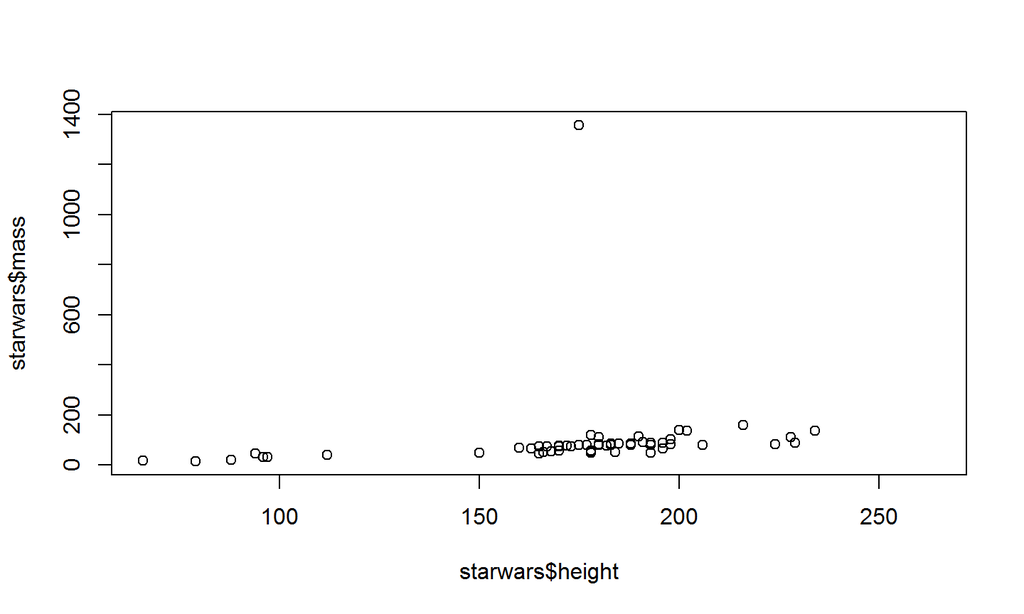

```r
plot(starwars$height, starwars$mass)
```

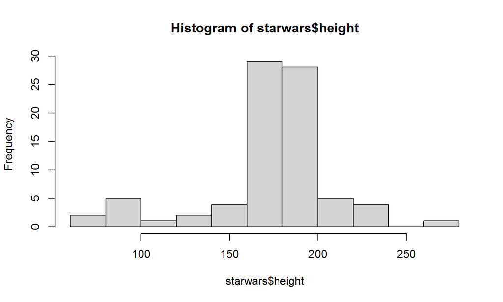

```r
hist(starwars$height)
```

## ggplot2

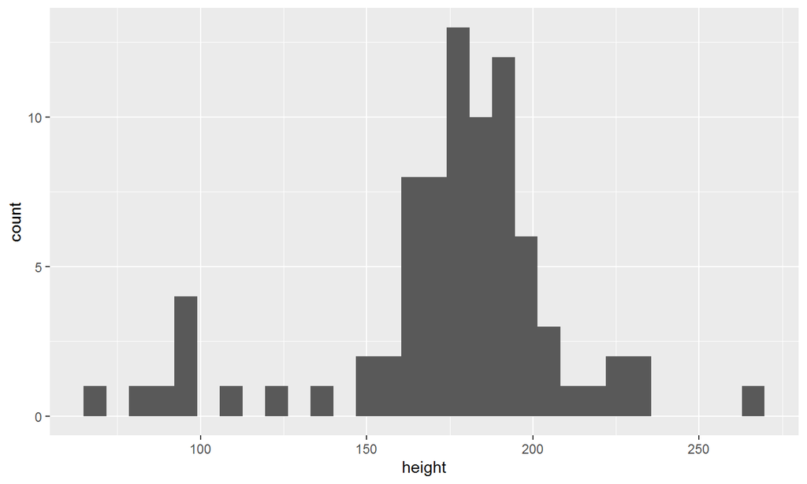

```r
library(ggplot2)
starwars %>% ggplot( aes( x = height)) + geom_histogram()
```

## map

```r
library(purrr)

map2(c(1,2,3,4), c(5,6,7,8), ~addition(.x, .y))
```

```
## [[1]]
## [1] 6
##
## [[2]]
## [1] 8
##
## [[3]]
## [1] 10
##
## [[4]]
## [1] 12
```

## Practical

## Course webpage

https://annevinkel.github.io/R-course-part-II/